# Weel10 Project4 - TextMining

humbertohp

November 4, 2018

## TextMining - Document Classification

#### It can be useful to be able to classify new “test” documents using already classified “training” documents. A common example is using a corpus of labeled spam and ham (non-spam) e-mails to predict whether or not a new document is spam.

#### For this project, you can start with a spam/ham dataset, then predict the class of new documents (either withheld from the training dataset or from another source such as your own spam folder). One example corpus: https://spamassassin.apache.org/publiccorpus/

### Installing necessary packages

```r
#install.packages("tm")
#install.packages("tidytext")
#install.packages("RTextTools")
```

## Analyzing Spam Email and uncovering Key Terms that can help with spam classification

### Defining spam and ham directory paths and building function for extracting only the message content (no email headers)

```r
setwd("C:/DATA/HHP/Personal/Degrees/Ms. Data Science (CUNY)/R Working Dir")
spam_path <- "C:/DATA/HHP/Personal/Degrees/Ms. Data Science (CUNY)/R Working Dir/spam_2/"
ham_path <- "C:/DATA/HHP/Personal/Degrees/Ms. Data Science (CUNY)/R Working Dir/easy_ham/"
get_msg <- function(path) {
  con <- file(path,open="rt",encoding="latin1")
  text <- readLines(con)
  msg <- text[seq(which(text=="")[1]+1,length(text))]
  close(con)
  return(paste(msg,collapse="\n"))
}
```

### Building spam and ham email datasets

```r
spam_files <- dir(spam_path)
spam_ds <- sapply(spam_files, function(p) get_msg(paste(spam_path, p, sep="")))
ham_files <- dir(ham_path)
ham_ds <- sapply(ham_files, function(p) get_msg(paste(ham_path, p, sep="")))
length(spam_ds)
```

```
## [1] 1396
```

```r
length(ham_ds)
```

```
## [1] 2500
```

### Create Corpus and Term-Document Matrices for spam and ham data sets

```r
library(tm)
control <- list(stopwords=TRUE, removePunctuation=TRUE, removeNumbers=TRUE, minDocFreq=2)
spam_corpus <- Corpus(VectorSource(spam_ds))
spam_tdm <- TermDocumentMatrix(spam_corpus, control)
ham_corpus <- Corpus(VectorSource(ham_ds))
ham_tdm <- TermDocumentMatrix(ham_corpus, control)
spam_tdm
```

```
## <<TermDocumentMatrix (terms: 34788, documents: 1396)>>
## Non-/sparse entries: 200489/48363559
## Sparsity           : 100%
## Maximal term length: 121
## Weighting          : term frequency (tf)
```

```r
ham_tdm
```

```
## <<TermDocumentMatrix (terms: 25280, documents: 2500)>>
## Non-/sparse entries: 208429/62991571
## Sparsity           : 100%
## Maximal term length: 76
## Weighting          : term frequency (tf)
```

### Removing sparse terms (80% of sparse percentage of empty)

```r
spam_tdm_unsprsd <- removeSparseTerms(spam_tdm, 0.8)
ham_tdm_unsprsd <- removeSparseTerms(ham_tdm, 0.8)
spam_tdm_unsprsd
```

```
## <<TermDocumentMatrix (terms: 79, documents: 1396)>>
## Non-/sparse entries: 37731/72553
## Sparsity           : 66%
## Maximal term length: 11
## Weighting          : term frequency (tf)
```

```r
ham_tdm_unsprsd
```

```
## <<TermDocumentMatrix (terms: 24, documents: 2500)>>
## Non-/sparse entries: 19242/40758
## Sparsity           : 68%
## Maximal term length: 8
## Weighting          : term frequency (tf)
```

### Top terms by frequency (mentioned at least 50 times)

```r
length(findFreqTerms(spam_tdm_unsprsd,50))
```

```
## [1] 79
```

```r
spam_topterms <- findFreqTerms(spam_tdm_unsprsd,50)
spam_topterms
```

```
##  [1] "address"     "business"    "click"       "email"       "form"
##  [6] "free"        "get"         "http"        "information" "just"
## [11] "like"        "list"        "listinfo"    "mailing"     "may"
## [16] "message"     "money"       "new"         "one"         "please"
## [21] "receive"     "send"        "subject"     "time"        "type"
## [26] "use"         "will"        "www"         "body"        "can"
## [31] "center"      "color"       "com"         "don"         "font"
## [36] "home"        "href"        "html"        "mail"        "mailto"
## [41] "make"        "name"        "now"         "right"       "today"
## [46] "remove"      "removed"     "want"        "nbsp"        "size"
## [51] "table"       "width"       "align"       "bgcolor"     "border"
## [56] "cellpadding" "cellspacing" "charset"     "content"     "div"
## [61] "equiv"       "face"        "ffffff"      "head"        "height"
## [66] "meta"        "net"         "text"        "title"       "arial"
## [71] "best"        "internet"    "top"         "link"        "helvetica"
## [76] "sans"        "serif"       "img"         "src"
```

```r
length(findFreqTerms(ham_tdm_unsprsd,50))
```

```
## [1] 24
```

```r
ham_topterms <- findFreqTerms(ham_tdm_unsprsd,50)
ham_topterms
```

```
##  [1] "can"      "com"      "date"     "get"      "like"     "list"
##  [7] "listinfo" "mailing"  "mailman"  "one"      "time"     "email"
## [13] "http"     "now"      "use"      "new"      "www"      "just"
## [19] "will"     "wrote"    "lists"    "net"      "don"      "url"
```

### Find top associations for the top 10 terms (lower correlation limit of 0.4)

```r
spam_assocs <- findAssocs(spam_tdm_unsprsd, spam_topterms[1:10], 0.4) ## more consistent association patterns found in spam
spam_assocs
```

```
## $address
##     send     mail     make      one     will     list      can internet
##     0.67     0.66     0.56     0.52     0.47     0.44     0.44     0.43
##      now     time
##     0.42     0.41
##
## $business
## money  html  home
##  0.55  0.46  0.42
##
## $click
## ffffff
##   0.42
##
## $email
## receive
##    0.43
##
## $form
##    name    type   width   right charset   align
##    0.67    0.64    0.50    0.42    0.42    0.40
##
## $free
##   can money   one  will  home   don today  best  want
##  0.63  0.61  0.56  0.54  0.51  0.47  0.46  0.45  0.41
##
## $get
##    money      can     will      one     home     make      don     send
##     0.74     0.72     0.68     0.66     0.57     0.56     0.54     0.48
##     want     like     time     font internet     best      com      now
##     0.47     0.46     0.46     0.46     0.46     0.45     0.43     0.42
##     face      use    today
##     0.42     0.41     0.41
##
## $http
##      www     href      com      div     size     font    align      net
##     0.97     0.94     0.76     0.74     0.71     0.56     0.54     0.53
##    color internet     nbsp
##     0.46     0.46     0.43
##
## $information
##      one      can     will      use      don     like     make     time
##     0.62     0.59     0.57     0.54     0.53     0.50     0.50     0.48
##     send     want  message      com   mailto    today      may internet
##     0.47     0.46     0.45     0.45     0.45     0.45     0.44     0.43
##  subject
##     0.42
##
## $just
##      can      one     will     make     like     send      don     time
##     0.80     0.79     0.73     0.71     0.69     0.67     0.64     0.59
##      use      now     want internet      com    today    money   mailto
##     0.55     0.52     0.52     0.52     0.51     0.50     0.49     0.47
##     best  receive     list  message
##     0.47     0.43     0.41     0.40
```

```r
ham_assocs <- findAssocs(ham_tdm_unsprsd, ham_topterms[1:10], 0.4) ## no consistent association patterns found in ham
ham_assocs
```

```
## $can
## will  new time just  use
## 0.72 0.63 0.59 0.50 0.49
##
## $com
##  www http
## 0.86 0.80
##
## $date
##  url
## 0.45
##
## $get
## numeric(0)
##
## $like
## just
## 0.43
##
## $list
##  net
## 0.54
##
## $listinfo
##   net lists
##  0.53  0.44
##
## $mailing
##   net lists
##  0.57  0.51
##
## $mailman
## numeric(0)
##
## $one
##  now
## 0.45
```

### Generate Master list of spam identification terms and create a wordcloud

```r
spam_id_terms <- setdiff(spam_topterms, ham_topterms)
spam_id_terms
```

```
##  [1] "address"     "business"    "click"       "form"        "free"
##  [6] "information" "may"         "message"     "money"       "please"
## [11] "receive"     "send"        "subject"     "type"        "body"
## [16] "center"      "color"       "font"        "home"        "href"
## [21] "html"        "mail"        "mailto"      "make"        "name"
## [26] "right"       "today"       "remove"      "removed"     "want"
## [31] "nbsp"        "size"        "table"       "width"       "align"
## [36] "bgcolor"     "border"      "cellpadding" "cellspacing" "charset"
## [41] "content"     "div"         "equiv"       "face"        "ffffff"
## [46] "head"        "height"      "meta"        "text"        "title"
## [51] "arial"       "best"        "internet"    "top"         "link"
## [56] "helvetica"   "sans"        "serif"       "img"         "src"
```

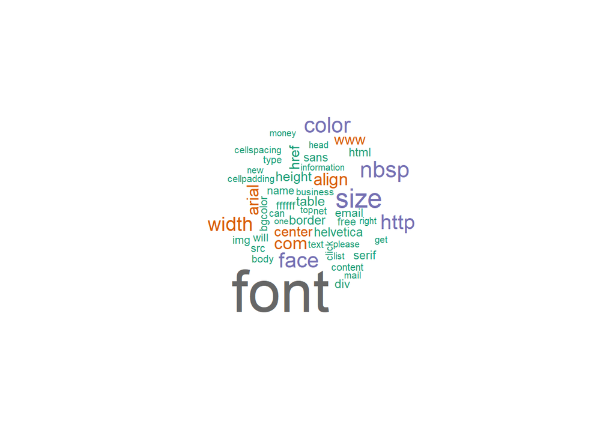

```r
library(wordcloud)
spam_tdm_cloud <- as.matrix(spam_tdm_unsprsd)
v <- sort(rowSums(spam_tdm_cloud),decreasing=TRUE)
d <- data.frame(word=names(v),freq=v)
wordcloud(d$word,d$freq,max.words=50, min.freq=50, colors=brewer.pal(8, 'Dark2'))
```

## Classification of emails (Spam and Ham)

### Creating a combined/scrambled spam+ham corpus and assigning labels

```r
spam_corpus <- VCorpus(VectorSource(spam_ds))
for (i in 1:length(spam_corpus)) {
  meta(spam_corpus[[i]], tag="emailtype") <- c("Spam")
}
ham_corpus <- VCorpus(VectorSource(ham_ds))
for (i in 1:length(ham_corpus)) {
  meta(ham_corpus[[i]], tag="emailtype") <- c("Ham")
}
email_corpus <- c(spam_corpus, ham_corpus)
email_corpus <- email_corpus[sample(c(1:length(email_corpus)))]
```

### Creating DTM and removing sparse terms (80% of sparse percentage of empty)

```r
controldtm <- list(stopwords=TRUE, removePunctuation=TRUE, removeNumbers=TRUE)
email_dtm <- DocumentTermMatrix(email_corpus, controldtm)
email_dtm
```

```
## <<DocumentTermMatrix (documents: 3896, terms: 70801)>>
## Non-/sparse entries: 407584/275433112
## Sparsity           : 100%
## Maximal term length: 868
## Weighting          : term frequency (tf)
```

```r
email_dtm_unsprsd <- removeSparseTerms(email_dtm, 0.8)
email_dtm_unsprsd
```

```
## <<DocumentTermMatrix (documents: 3896, terms: 17)>>
## Non-/sparse entries: 17927/48305
## Sparsity           : 73%
## Maximal term length: 7
## Weighting          : term frequency (tf)
```

```r
inspect(email_dtm_unsprsd[1:10,1:10])
```

```
## <<DocumentTermMatrix (documents: 10, terms: 10)>>
## Non-/sparse entries: 22/78
## Sparsity           : 78%
## Maximal term length: 7
## Weighting          : term frequency (tf)
## Sample             :
##       Terms
## Docs   can date email free get just like list mailing message
##   1139   0    0     0    0   0    2    0    2       1       0
##   1217   0    0     0    0   1    0    0    0       0       0
##   1677   0    0     4    0   0    0    1    0       0       1
##   1769   2    0     0    0   0    0    0    0       0       1
##   2008   0    1     0    0   0    0    0    0       0       0
##   212    0    0     0    0   2    0    0    2       0       5
##   2355   0    1     0    0   0    0    0    0       0       0
##   256    0    0     2    4   0    0    0    2       2       3
##   785    0    0     0    0   0    0    0    0       0       0
##   974    0    0     0    0   0    0    1    1       1       0
```

### Creating Container with all relevant information to use in the classification procedure

```r
library(RTextTools)
email_labels <- unlist(meta(email_corpus, "emailtype"))
N <- length(email_labels)
splitN <- round(0.7*N)
table(email_labels)
```

```
## email_labels
##  Ham Spam
## 2500 1396
```

```r
container_email <- create_container(email_dtm_unsprsd, labels = email_labels, trainSize = 1:splitN, testSize = splitN:N, virgin = FALSE)
```

```r
svm_model <- train_model(container_email, "SVM")
tree_model <- train_model(container_email, "TREE")
maxent_model <- train_model(container_email, "MAXENT")
```

### Scoring Emails (Spam and Ham)

```r
svm_score <- classify_model(container_email, svm_model)
tree_score <- classify_model(container_email, tree_model)
maxent_score <- classify_model(container_email, maxent_model)
```

### Presenting Results

```r
library(knitr)
table(email_labels[splitN:N])
```

```
##
##  Ham Spam
##  751  419
```

```r
table(as.character(svm_score[,1]))
```

```
##
##  Ham Spam
##  742  428
```

```r
table(as.character(tree_score[,1]))
```

```
##
##  Ham Spam
##  742  428
```

```r
table(as.character(maxent_score[,1]))
```

```
##
##  Ham Spam
##  803  367
```

```r
results <- data.frame(
  email_labels[splitN:N],
  as.character(svm_score[,1]),
  as.character(tree_score[,1]),
  as.character(maxent_score[,1]))

colnames(results) <- c("CorrectLabel", "SVM", "DTree", "MaxEntropy")
kable(summary(results))
```

|  | CorrectLabel | SVM | DTree | MaxEntropy |
| --- | --- | --- | --- | --- |
|  | Ham :751 | Ham :742 | Ham :742 | Ham :803 |
|  | Spam:419 | Spam:428 | Spam:428 | Spam:367 |